# Final Project_Andi SARIMA

```python
import pandas as pd

# Load the dataset
file_path1 = "air traffic.csv"
file_path2 = "U.S._Gulf_Coast_Kerosene-Type_Jet_Fuel_Spot_Price_FOB.csv"
file_path3 = "US-Monthly-GDP-History-Data.xlsx"

air_traffic = pd.read_csv(file_path1)
jet_fuel_price = pd.read_csv(file_path2)
gdp_history = pd.read_excel(file_path3, sheet_name="Data")
```

```python
print(air_traffic.info())
print(air_traffic.head())
```

```
<class 'pandas.core.frame.DataFrame'>
RangeIndex: 249 entries, 0 to 248
Data columns (total 17 columns):
 #   Column   Non-Null Count  Dtype
---  ------   --------------  -----
 0   Year     249 non-null    int64
 1   Month    249 non-null    int64
 2   Dom_Pax  249 non-null    object
 3   Int_Pax  249 non-null    object
 4   Pax      249 non-null    object
 5   Dom_Flt  249 non-null    object
 6   Int_Flt  249 non-null    object
 7   Flt      249 non-null    object
 8   Dom_RPM  249 non-null    object
 9   Int_RPM  249 non-null    object
```

[output cut: 30 more lines]

```python
print(jet_fuel_price.info())
print(jet_fuel_price.head)
```

```
<class 'pandas.core.frame.DataFrame'>
RangeIndex: 418 entries, 0 to 417
Data columns (total 2 columns):
 #   Column                                                                    Non-Null Count  Dtype
---  ------                                                                    --------------  -----
 0   Month                                                                     418 non-null    object
 1   U.S. Gulf Coast Kerosene-Type Jet Fuel Spot Price FOB Dollars per Gallon  418 non-null    float64
dtypes: float64(1), object(1)
memory usage: 6.7+ KB
None
<bound method NDFrame.head of       Month  \
0    Jan-25
1    Dec-24
2    Nov-24
3    Oct-24
4    Sep-24
..      ...
413  Aug-90
414  Jul-90
415  Jun-90
416  May-90
417  Apr-90

     U.S. Gulf Coast Kerosene-Type Jet Fuel Spot Price FOB Dollars per Gallon
0                                                2.347
1                                                2.097
2                                                2.065
3                                                2.068
4                                                1.982
..                                                 ...
413                                              0.791
414                                              0.535
415                                              0.494
416                                              0.515
417                                              0.540

[418 rows x 2 columns]>
```

```python
print(gdp_history.info())
print(gdp_history.head())
```

```
<class 'pandas.core.frame.DataFrame'>
RangeIndex: 396 entries, 0 to 395
Data columns (total 3 columns):
 #   Column                     Non-Null Count  Dtype
---  ------                     --------------  -----
 0   Year-Month                 396 non-null    object
 1   Monthly Nominal GDP Index  396 non-null    float64
 2   Monthly Real GDP Index     396 non-null    float64
dtypes: float64(2), object(1)
memory usage: 9.4+ KB
None
   Year-Month  Monthly Nominal GDP Index  Monthly Real GDP Index
0  1992 - Jan                6315.717831            10177.761101
1  1992 - Feb                6356.509042            10222.923620
2  1992 - Mar                6417.079126            10308.007112
3  1992 - Apr                6443.257970            10314.281702
4  1992 - May                6433.800593            10293.476332
```

### Data Preprocessing & EDA for air_traffic

```python
# Convert Year and Month into a datetime column
air_traffic['Date'] = pd.to_datetime(air_traffic['Year'].astype(str) + '-' + air_traffic['Month'].astype(str) + '-01')

# Set the Date column as the index (important for time series analysis)
air_traffic.set_index('Date', inplace=True)

# Drop the original Year and Month columns
air_traffic.drop(columns=['Year', 'Month'], inplace=True)

print(air_traffic.info())
print(air_traffic.head())
```

```
<class 'pandas.core.frame.DataFrame'>
DatetimeIndex: 249 entries, 2003-01-01 to 2023-09-01
Data columns (total 15 columns):
 #   Column   Non-Null Count  Dtype
---  ------   --------------  -----
 0   Dom_Pax  249 non-null    object
 1   Int_Pax  249 non-null    object
 2   Pax      249 non-null    object
 3   Dom_Flt  249 non-null    object
 4   Int_Flt  249 non-null    object
 5   Flt      249 non-null    object
 6   Dom_RPM  249 non-null    object
 7   Int_RPM  249 non-null    object
 8   RPM      249 non-null    object
 9   Dom_ASM  249 non-null    object
 10  Int_ASM  249 non-null    object
 11  ASM      249 non-null    object
 12  Dom_LF   249 non-null    float64
 13  Int_LF   249 non-null    float64
 14  LF       249 non-null    float64
dtypes: float64(3), object(12)
memory usage: 31.1+ KB
None
               Dom_Pax    Int_Pax         Pax  Dom_Flt Int_Flt      Flt  \
Date
2003-01-01  43,032,450  4,905,830  47,938,280  785,160  57,667  842,827
2003-02-01  41,166,780  4,245,366  45,412,146  690,351  51,259  741,610
2003-03-01  49,992,700  5,008,613  55,001,313  797,194  58,926  856,120
2003-04-01  47,033,260  4,345,444  51,378,704  766,260  55,005  821,265
2003-05-01  49,152,352  4,610,834  53,763,186  789,397  55,265  844,662

               Dom_RPM     Int_RPM         RPM     Dom_ASM     Int_ASM  \
Date
2003-01-01  36,211,422  12,885,980  49,097,402  56,191,300  17,968,572
2003-02-01  34,148,439  10,715,468  44,863,907  50,088,434  15,587,880
2003-03-01  41,774,564  12,567,068  54,341,633  57,592,901  17,753,174
2003-04-01  39,465,980  10,370,592  49,836,572  54,639,679  15,528,761
2003-05-01  41,001,934  11,575,026  52,576,960  55,349,897  15,629,821

                   ASM  Dom_LF  Int_LF     LF
Date
2003-01-01  74,159,872   64.44   71.71  66.20
2003-02-01  65,676,314   68.18   68.74  68.31
2003-03-01  75,346,075   72.53   70.79  72.12
2003-04-01  70,168,440   72.23   66.78  71.02
2003-05-01  70,979,718   74.08   74.06  74.07
```

```python
# Change Object variables to numerical variables

def clean_numeric_column(column):
    return pd.to_numeric(column.astype(str).str.replace(',', ''), errors='coerce')

object_columns = air_traffic.select_dtypes(include=['object']).columns

for col in object_columns:
    air_traffic[col] = clean_numeric_column(air_traffic[col])

air_traffic.info()
```

```
<class 'pandas.core.frame.DataFrame'>
DatetimeIndex: 249 entries, 2003-01-01 to 2023-09-01
Data columns (total 15 columns):
 #   Column   Non-Null Count  Dtype
---  ------   --------------  -----
 0   Dom_Pax  249 non-null    int64
 1   Int_Pax  249 non-null    int64
 2   Pax      249 non-null    int64
 3   Dom_Flt  249 non-null    int64
 4   Int_Flt  249 non-null    int64
 5   Flt      249 non-null    int64
 6   Dom_RPM  249 non-null    int64
 7   Int_RPM  249 non-null    int64
 8   RPM      249 non-null    int64
 9   Dom_ASM  249 non-null    int64
 10  Int_ASM  249 non-null    int64
 11  ASM      249 non-null    int64
 12  Dom_LF   249 non-null    float64
 13  Int_LF   249 non-null    float64
 14  LF       249 non-null    float64
dtypes: float64(3), int64(12)
memory usage: 31.1 KB
```

```python
print(air_traffic.head())
```

```
             Dom_Pax  Int_Pax       Pax  Dom_Flt  Int_Flt     Flt   Dom_RPM  \
Date
2003-01-01  43032450  4905830  47938280   785160    57667  842827  36211422
2003-02-01  41166780  4245366  45412146   690351    51259  741610  34148439
2003-03-01  49992700  5008613  55001313   797194    58926  856120  41774564
2003-04-01  47033260  4345444  51378704   766260    55005  821265  39465980
2003-05-01  49152352  4610834  53763186   789397    55265  844662  41001934

             Int_RPM       RPM   Dom_ASM   Int_ASM       ASM  Dom_LF  Int_LF  \
Date
2003-01-01  12885980  49097402  56191300  17968572  74159872   64.44   71.71
2003-02-01  10715468  44863907  50088434  15587880  65676314   68.18   68.74
2003-03-01  12567068  54341633  57592901  17753174  75346075   72.53   70.79
2003-04-01  10370592  49836572  54639679  15528761  70168440   72.23   66.78
2003-05-01  11575026  52576960  55349897  15629821  70979718   74.08   74.06

               LF
Date
2003-01-01  66.20
2003-02-01  68.31
2003-03-01  72.12
2003-04-01  71.02
2003-05-01  74.07
```

```python
import pandas as pd

# Create a summary DataFrame for null values in each dataset
null_summary = pd.DataFrame({
    "Air Traffic": air_traffic.isnull().sum(),
    "Jet Fuel Price": jet_fuel_price.isnull().sum(),
    "GDP History": gdp_history.isnull().sum()
})

null_summary

# It seems that for all of the 3 dataframes, there is no null value in any column.
```

|  | Air Traffic | Jet Fuel Price | GDP History |
| --- | --- | --- | --- |
| ASM | 0.0 | NaN | NaN |
| Dom_ASM | 0.0 | NaN | NaN |
| Dom_Flt | 0.0 | NaN | NaN |
| Dom_LF | 0.0 | NaN | NaN |
| Dom_Pax | 0.0 | NaN | NaN |
| Dom_RPM | 0.0 | NaN | NaN |
| Flt | 0.0 | NaN | NaN |
| Int_ASM | 0.0 | NaN | NaN |
| Int_Flt | 0.0 | NaN | NaN |
| Int_LF | 0.0 | NaN | NaN |
| Int_Pax | 0.0 | NaN | NaN |
| Int_RPM | 0.0 | NaN | NaN |
| LF | 0.0 | NaN | NaN |
| Month | NaN | 0.0 | NaN |
| Monthly Nominal GDP Index | NaN | NaN | 0.0 |
| Monthly Real GDP Index | NaN | NaN | 0.0 |
| Pax | 0.0 | NaN | NaN |
| RPM | 0.0 | NaN | NaN |
| U.S. Gulf Coast Kerosene-Type Jet Fuel Spot Price FOB Dollars per Gallon | NaN | 0.0 | NaN |
| Year-Month | NaN | NaN | 0.0 |

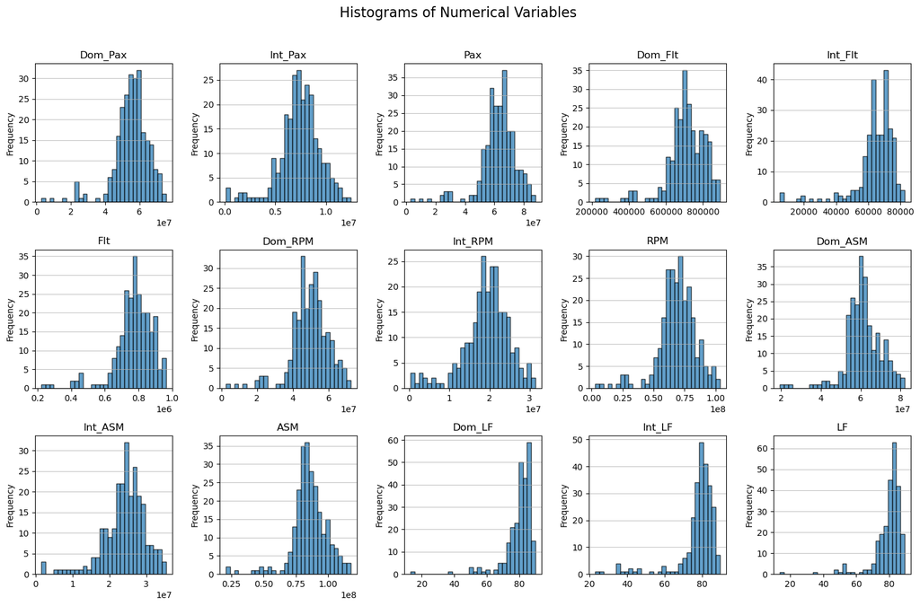

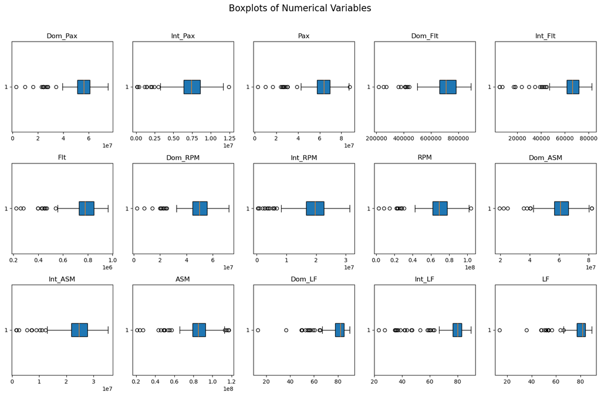

```python
import matplotlib.pyplot as plt
import numpy as np

def plot_distributions(df):
    numeric_columns = df.select_dtypes(include=['number']).columns
    num_cols = len(numeric_columns)

    rows, cols = 3, 5
    total_plots = rows * cols

    num_hist_plots = min(num_cols, total_plots)
    num_box_plots = min(num_cols, total_plots)

    # Plot Histograms
    fig, axes = plt.subplots(rows, cols, figsize=(15, 10))
    fig.suptitle('Histograms of Numerical Variables', fontsize=16)

    for i, col in enumerate(numeric_columns[:num_hist_plots]):
        ax = axes[i // cols, i % cols]
        ax.hist(df[col].dropna(), bins=30, edgecolor='black', alpha=0.7)
        ax.set_title(col)
        ax.set_ylabel('Frequency')
        ax.grid(axis='y', alpha=0.75)

    plt.tight_layout(rect=[0, 0, 1, 0.96])
    plt.show()

    # Plot Boxplots
    fig, axes = plt.subplots(rows, cols, figsize=(15, 10))
    fig.suptitle('Boxplots of Numerical Variables', fontsize=16)

    for i, col in enumerate(numeric_columns[:num_box_plots]):
        ax = axes[i // cols, i % cols]
        ax.boxplot(df[col].dropna(), vert=False, patch_artist=True)
        ax.set_title(col)

    plt.tight_layout(rect=[0, 0, 1, 0.96])
    plt.show()

plot_distributions(air_traffic)
```

```python
# Log transformation for skewed data

skewed_columns = ['Dom_Pax', 'Int_Pax', 'Pax', 'Dom_Flt', 'Int_Flt', 'Flt',
                  'Dom_RPM', 'Int_RPM', 'RPM', 'Dom_ASM', 'Int_ASM', 'ASM']

for col in skewed_columns:
    air_traffic[col] = np.log1p(air_traffic[col])
```

```python
# Normalization

from sklearn.preprocessing import MinMaxScaler

scaler = MinMaxScaler()
scaled_columns = ['Dom_Pax', 'Int_Pax', 'Pax', 'Dom_Flt', 'Int_Flt', 'Flt',
                  'Dom_RPM', 'Int_RPM', 'RPM', 'Dom_ASM', 'Int_ASM', 'ASM',
                  'Dom_LF', 'Int_LF', 'LF']

air_traffic[scaled_columns] = scaler.fit_transform(air_traffic[scaled_columns])
```

```python
air_traffic.describe()
```

|  | Dom_Pax | Int_Pax | Pax | Dom_Flt | Int_Flt | Flt | Dom_RPM | Int_RPM | RPM | Dom_ASM | Int_ASM | ASM | Dom_LF | Int_LF | LF |
| --- | --- | --- | --- | --- | --- | --- | --- | --- | --- | --- | --- | --- | --- | --- | --- |
| count | 249.000000 | 249.000000 | 249.000000 | 249.000000 | 249.000000 | 249.000000 | 249.000000 | 249.000000 | 249.000000 | 249.000000 | 249.000000 | 249.000000 | 249.000000 | 249.000000 | 249.000000 |
| mean | 0.895421 | 0.868667 | 0.889942 | 0.825377 | 0.899952 | 0.837798 | 0.877122 | 0.870092 | 0.873509 | 0.788663 | 0.863314 | 0.805651 | 0.869629 | 0.816940 | 0.869158 |
| std | 0.091624 | 0.111409 | 0.092783 | 0.132294 | 0.121024 | 0.129887 | 0.093564 | 0.124058 | 0.098250 | 0.120282 | 0.120363 | 0.118830 | 0.115267 | 0.164537 | 0.118121 |
| min | 0.000000 | 0.000000 | 0.000000 | 0.000000 | 0.000000 | 0.000000 | 0.000000 | 0.000000 | 0.000000 | 0.000000 | 0.000000 | 0.000000 | 0.000000 | 0.000000 | 0.000000 |
| 25% | 0.880257 | 0.852624 | 0.875282 | 0.789530 | 0.895202 | 0.808462 | 0.855529 | 0.857827 | 0.855425 | 0.741470 | 0.844863 | 0.771425 | 0.840770 | 0.803741 | 0.838003 |
| 50% | 0.910095 | 0.885555 | 0.905729 | 0.839067 | 0.922696 | 0.854714 | 0.888989 | 0.895910 | 0.886169 | 0.792854 | 0.885048 | 0.812913 | 0.898010 | 0.856238 | 0.899615 |
| 75% | 0.934649 | 0.917466 | 0.930422 | 0.907402 | 0.950331 | 0.913069 | 0.922032 | 0.927378 | 0.920599 | 0.851779 | 0.922412 | 0.862078 | 0.938598 | 0.901795 | 0.932678 |
| max | 1.000000 | 1.000000 | 1.000000 | 1.000000 | 1.000000 | 1.000000 | 1.000000 | 1.000000 | 1.000000 | 1.000000 | 1.000000 | 1.000000 | 1.000000 | 1.000000 | 1.000000 |

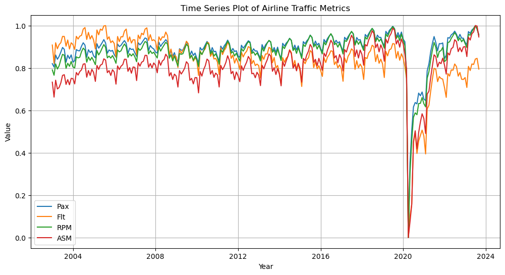

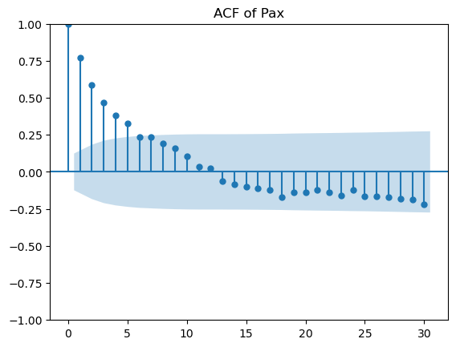

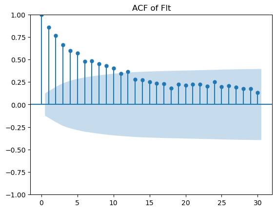

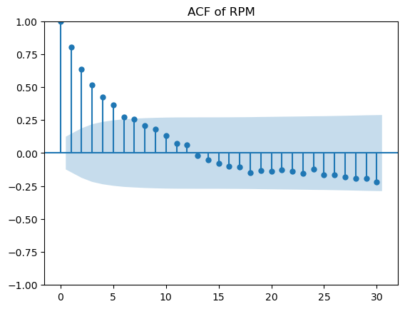

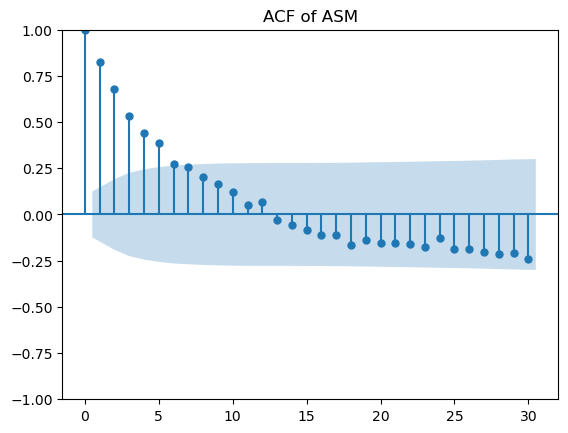

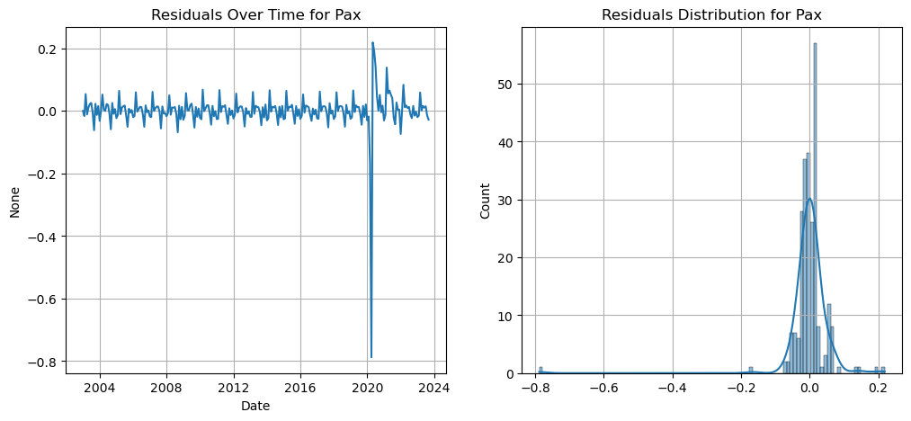

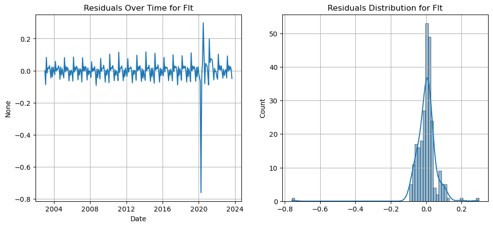

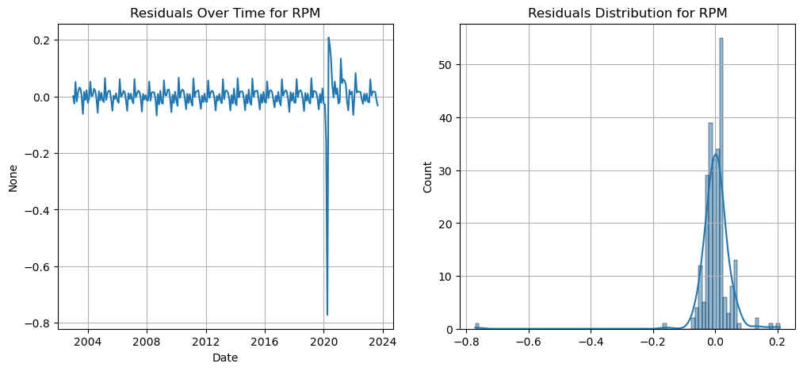

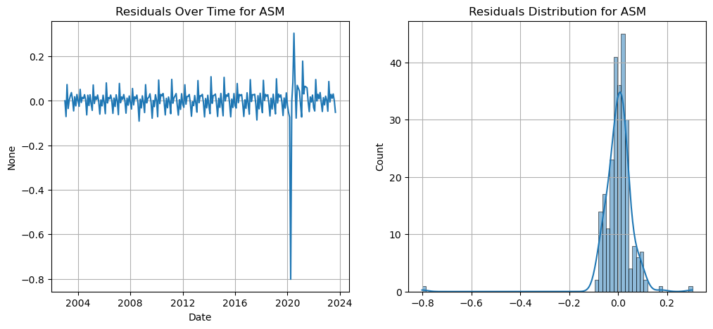

```python
import matplotlib.pyplot as plt
import seaborn as sns
import statsmodels.api as sm
from statsmodels.graphics.tsaplots import plot_acf, plot_pacf

# Define target variables
target_variables = ['Pax', 'Flt', 'RPM', 'ASM']  # Only Selected Total Columns Here

# Plot Time Series
plt.figure(figsize=(12, 6))
for var in target_variables:
    plt.plot(air_traffic.index, air_traffic[var], label=var)

plt.title("Time Series Plot of Airline Traffic Metrics")
plt.xlabel("Year")
plt.ylabel("Value")
plt.legend()
plt.grid()
plt.show()

# ACF Plot
for var in target_variables:
    plt.figure(figsize=(8, 4))
    plot_acf(air_traffic[var].dropna(), lags=30, title=f"ACF of {var}")
    plt.show()

# Residual Diagnostics
for var in target_variables:
    # Fit a simple time series model to extract residuals
    model = sm.tsa.SimpleExpSmoothing(air_traffic[var].dropna()).fit()
    residuals = model.resid

    fig, ax = plt.subplots(1, 2, figsize=(12, 5))

    # Residuals time series
    sns.lineplot(x=air_traffic.index, y=residuals, ax=ax[0])
    ax[0].set_title(f"Residuals Over Time for {var}")
    ax[0].grid()

    # Residuals distribution
    sns.histplot(residuals, kde=True, ax=ax[1])
    ax[1].set_title(f"Residuals Distribution for {var}")
    ax[1].grid()

    plt.show()
```

The first plot shows the time series of airline traffic metrics, including passengers (Pax), flights (Flt), revenue passenger miles (RPM), and available seat miles (ASM). The series follows a seasonal trend with a significant drop around 2020 due to COVID, followed by a recovery. The autocorrelation function (ACF) plots for each metric indicate strong autocorrelation at lower lags, suggesting that past values strongly influence future values. The residual plots show that while the model captures most patterns, there are deviations, particularly during the pandemic period, indicating external shocks affecting airline traffic.

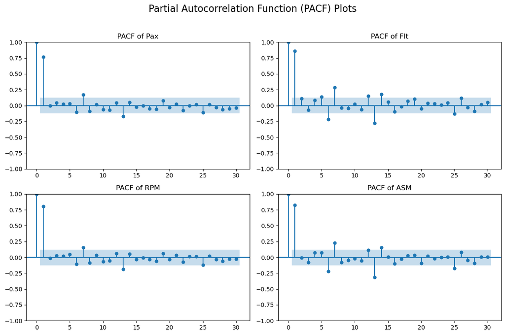

```python
from statsmodels.tsa.stattools import adfuller

# PACF Plots
fig, axes = plt.subplots(2, 2, figsize=(12, 8))
fig.suptitle("Partial Autocorrelation Function (PACF) Plots", fontsize=16)

for i, var in enumerate(target_variables):
    row, col = divmod(i, 2)  # Get subplot row and column position
    sm.graphics.tsa.plot_pacf(air_traffic[var].dropna(), lags=30, method='ywm', ax=axes[row, col], title=f"PACF of {var}")

plt.tight_layout(rect=[0, 0, 1, 0.96])
plt.show()
```

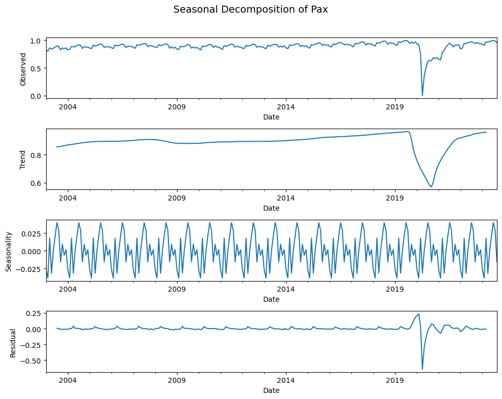

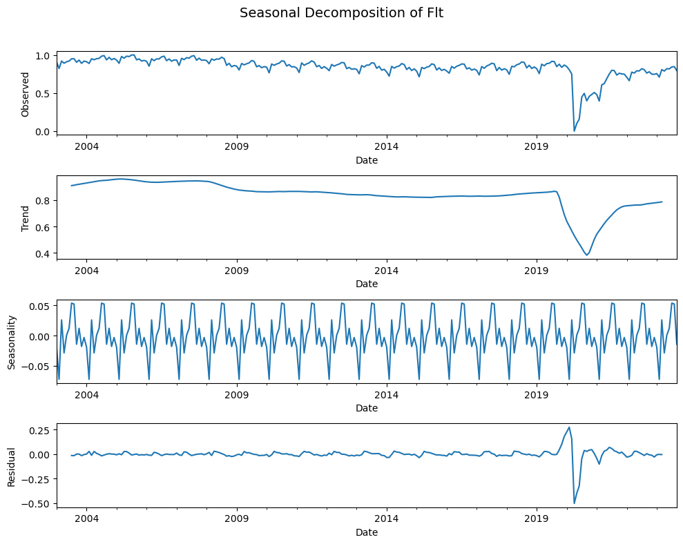

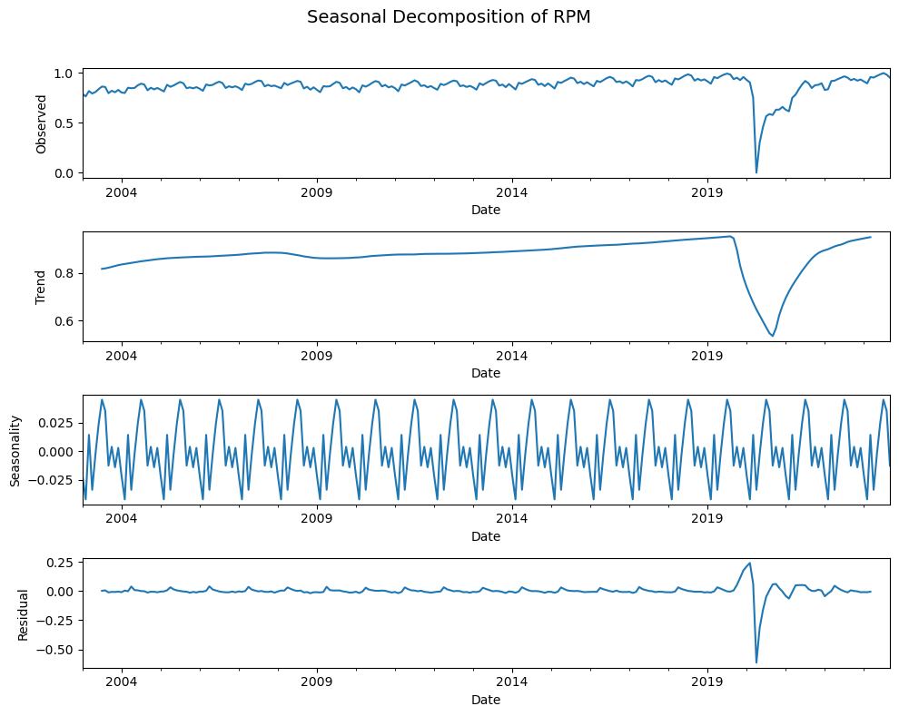

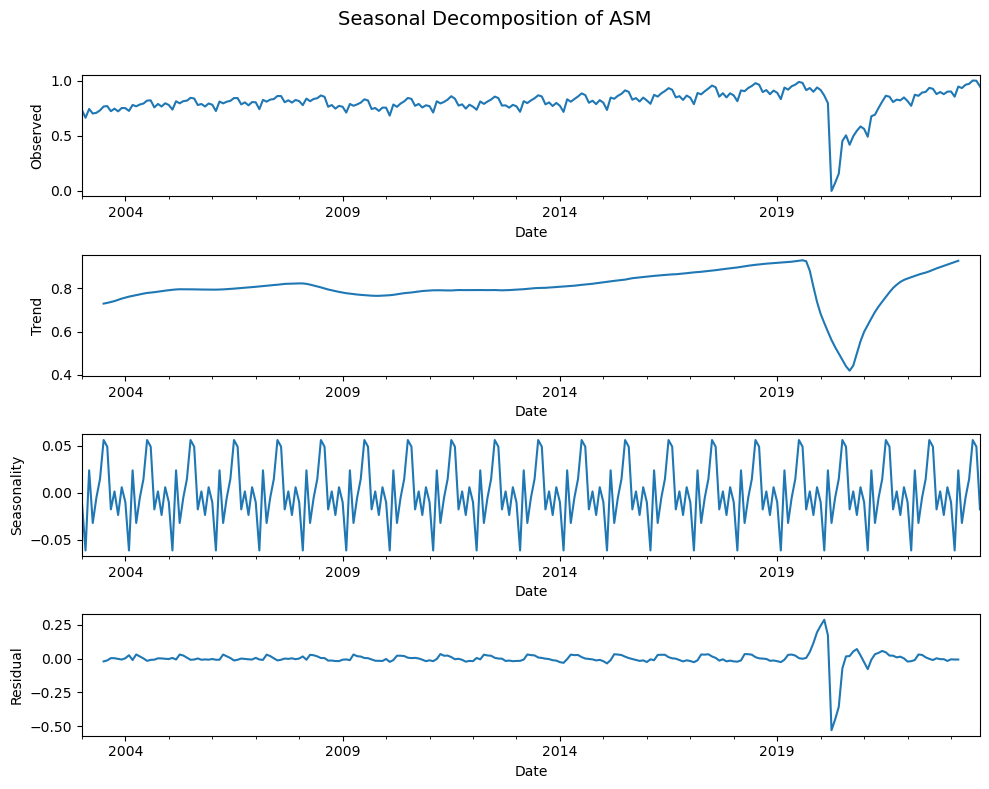

```python
from statsmodels.tsa.seasonal import seasonal_decompose
import matplotlib.pyplot as plt

# Perform seasonal decomposition
for var in ['Pax', 'Flt', 'RPM', 'ASM']:
    decomposition = seasonal_decompose(air_traffic[var].dropna(), model='additive', period=12)  # Assuming monthly data

    # Plot decomposition
    fig, axes = plt.subplots(4, 1, figsize=(10, 8))
    fig.suptitle(f"Seasonal Decomposition of {var}", fontsize=14)

    decomposition.observed.plot(ax=axes[0], legend=False)
    axes[0].set_ylabel("Observed")

    decomposition.trend.plot(ax=axes[1], legend=False)
    axes[1].set_ylabel("Trend")

    decomposition.seasonal.plot(ax=axes[2], legend=False)
    axes[2].set_ylabel("Seasonality")

    decomposition.resid.plot(ax=axes[3], legend=False)
    axes[3].set_ylabel("Residual")

    plt.tight_layout(rect=[0, 0, 1, 0.96])
    plt.show()
```

The PACF plots indicate that the airline traffic metrics have a strong immediate lag-1 correlation, suggesting that past values significantly influence current values. However, higher-order lags quickly diminish, indicating a short-term dependency structure. The seasonal decomposition plots reveal clear long-term trends and strong seasonality across all metrics, with a substantial drop around 2020 due to the pandemic, followed by a gradual recovery. The residual plots show mostly stable patterns.

```python
# Remove data from 2020 and 2021 for long-term trend

air_traffic_filtered = air_traffic.loc[~((air_traffic.index.year >= 2020) & (air_traffic.index.year <= 2021))]
print(air_traffic_filtered.head())
```

```
             Dom_Pax   Int_Pax       Pax   Dom_Flt   Int_Flt       Flt  \
Date
2003-01-01  0.828347  0.793857  0.820499  0.910438  0.871604  0.908376
2003-02-01  0.814774  0.761803  0.804444  0.819246  0.829628  0.821181
2003-03-01  0.874255  0.798454  0.861259  0.921217  0.879301  0.919042
2003-04-01  0.855569  0.766968  0.841053  0.893171  0.854763  0.890714
2003-05-01  0.869064  0.780110  0.854507  0.914252  0.856443  0.909859

             Dom_RPM   Int_RPM       RPM   Dom_ASM   Int_ASM       ASM  \
Date
2003-01-01  0.793350  0.801216  0.790920  0.736973  0.784158  0.733187
2003-02-01  0.775808  0.760013  0.765686  0.656956  0.738777  0.662510
2003-03-01  0.836089  0.795618  0.819319  0.754120  0.780307  0.742419
2003-04-01  0.819088  0.752706  0.795101  0.717485  0.737563  0.701000
2003-05-01  0.830506  0.777249  0.810081  0.726473  0.739635  0.707688

              Dom_LF    Int_LF        LF
Date
2003-01-01  0.668011  0.732539  0.695392
2003-02-01  0.716664  0.687736  0.723410
2003-03-01  0.773254  0.718660  0.774001
2003-04-01  0.769351  0.658169  0.759395
2003-05-01  0.793417  0.767989  0.799894
```

### Preprocessing and EDA for gdp_history and jet_fuel_price

```python
# gdp_history
# Change Year-Month into time format

gdp_history["Year-Month"] = (
    gdp_history["Year-Month"]
    .astype(str)
    .str.replace("–", "-", regex=True)
    .str.replace(r"\s*-\s*", "-", regex=True)
    .str.strip()
)

gdp_history["Year-Month"] = pd.to_datetime(gdp_history["Year-Month"], format="%Y-%b", errors="coerce").dt.to_period("M")

print(gdp_history.head())
```

```
  Year-Month  Monthly Nominal GDP Index  Monthly Real GDP Index
0    1992-01                6315.717831            10177.761101
1    1992-02                6356.509042            10222.923620
2    1992-03                6417.079126            10308.007112
3    1992-04                6443.257970            10314.281702
4    1992-05                6433.800593            10293.476332
```

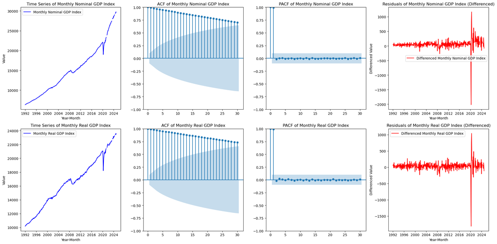

```python
gdp_history["Year-Month"] = gdp_history["Year-Month"].dt.to_timestamp()

fig, axes = plt.subplots(2, 4, figsize=(20, 10))

gdp_columns = ["Monthly Nominal GDP Index", "Monthly Real GDP Index"]

for i, col in enumerate(gdp_columns):
    # Time Series Plot
    axes[i, 0].plot(gdp_history["Year-Month"], gdp_history[col], label=col, color='b')
    axes[i, 0].set_title(f"Time Series of {col}")
    axes[i, 0].set_xlabel("Year-Month")
    axes[i, 0].set_ylabel("Value")
    axes[i, 0].legend()

    # ACF Plot
    sm.graphics.tsa.plot_acf(gdp_history[col].dropna(), lags=30, ax=axes[i, 1])
    axes[i, 1].set_title(f"ACF of {col}")

    # PACF Plot
    sm.graphics.tsa.plot_pacf(gdp_history[col].dropna(), lags=30, ax=axes[i, 2])
    axes[i, 2].set_title(f"PACF of {col}")

    # Residuals Plot (First-order differencing)
    diff_series = gdp_history[col].diff().dropna()
    axes[i, 3].plot(gdp_history["Year-Month"][1:], diff_series, label=f"Differenced {col}", color='r')
    axes[i, 3].set_title(f"Residuals of {col} (Differenced)")
    axes[i, 3].set_xlabel("Year-Month")
    axes[i, 3].set_ylabel("Differenced Value")
    axes[i, 3].legend()

plt.tight_layout()
plt.show()
```

The time series plots of Monthly Nominal GDP Index and Monthly Real GDP Index show strong upward trends, indicating non-stationarity. The ACF plots display slow decay, confirming persistent autocorrelation, while the PACF plots show a sharp drop after lag 1, suggesting a need for first-order differencing. The residual plots after differencing exhibit more stability but reveal large spikes around 2020. Data around 2020 will be removed for long-term trend forecasting.

```python
# jet_fuel_price
# Change Month into time format

jet_fuel_price["Month"] = pd.to_datetime(jet_fuel_price["Month"], format="%b-%y").dt.to_period("M")
print(jet_fuel_price.head())
```

```
     Month  \
0  2025-01
1  2024-12
2  2024-11
3  2024-10
4  2024-09

   U.S. Gulf Coast Kerosene-Type Jet Fuel Spot Price FOB Dollars per Gallon
0                                              2.347
1                                              2.097
2                                              2.065
3                                              2.068
4                                              1.982
```

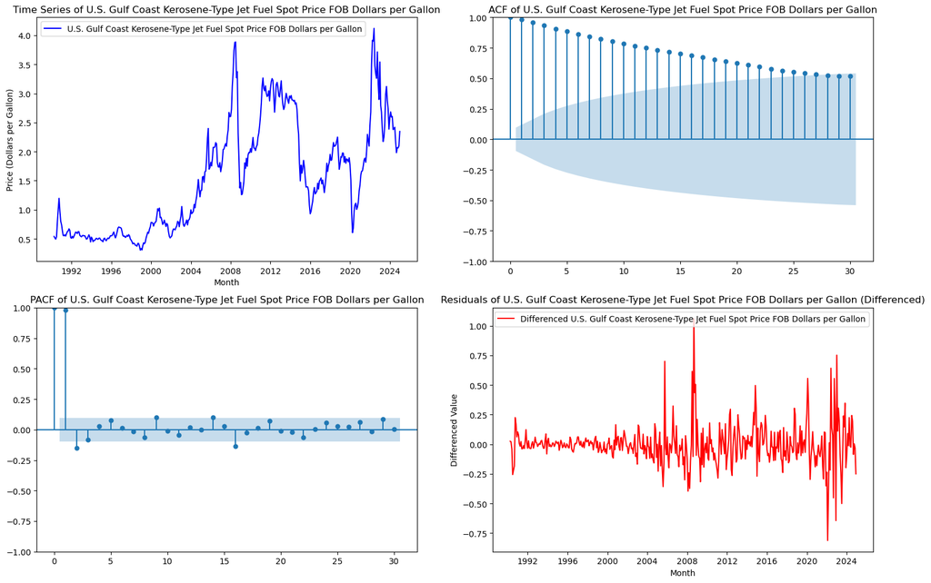

```python
jet_fuel_price["Month"] = jet_fuel_price["Month"].dt.to_timestamp()
fig, axes = plt.subplots(2, 2, figsize=(15, 10))

col = "U.S. Gulf Coast Kerosene-Type Jet Fuel Spot Price FOB Dollars per Gallon"

# Time Series Plot
axes[0, 0].plot(jet_fuel_price["Month"], jet_fuel_price[col], label=col, color='b')
axes[0, 0].set_title(f"Time Series of {col}")
axes[0, 0].set_xlabel("Month")
axes[0, 0].set_ylabel("Price (Dollars per Gallon)")
axes[0, 0].legend()

# ACF Plot
sm.graphics.tsa.plot_acf(jet_fuel_price[col].dropna(), lags=30, ax=axes[0, 1])
axes[0, 1].set_title(f"ACF of {col}")

# PACF Plot
sm.graphics.tsa.plot_pacf(jet_fuel_price[col].dropna(), lags=30, ax=axes[1, 0])
axes[1, 0].set_title(f"PACF of {col}")

# Residuals Plot (First-order differencing)
diff_series = jet_fuel_price[col].diff().dropna()
axes[1, 1].plot(jet_fuel_price["Month"][1:], diff_series, label=f"Differenced {col}", color='r')
axes[1, 1].set_title(f"Residuals of {col} (Differenced)")
axes[1, 1].set_xlabel("Month")
axes[1, 1].set_ylabel("Differenced Value")
axes[1, 1].legend()

plt.tight_layout()
plt.show()
```

The time series plot of jet fuel prices shows strong volatility with clear upward trends and sharp fluctuations, particularly around 2008 and 2022, which is related to economic or geopolitical shocks. The ACF plot indicates a slow decay, confirming strong autocorrelation and trend persistence. The PACF plot has a significant lag-1 spike, suggesting that a first-order differencing (d=1) may help in making the series stationary. The residual plot after differencing shows reduced trend effects but retains volatility, I'll use box-cox transformation to stabilize volatility.

```python
from scipy.stats import boxcox

jet_fuel_price["Transformed_Price"], lambda_val = boxcox(
    jet_fuel_price["U.S. Gulf Coast Kerosene-Type Jet Fuel Spot Price FOB Dollars per Gallon"]
)

print(f"Optimal λ for Box-Cox: {lambda_val}")
```

```
Optimal λ for Box-Cox: 0.15120407176996906
```

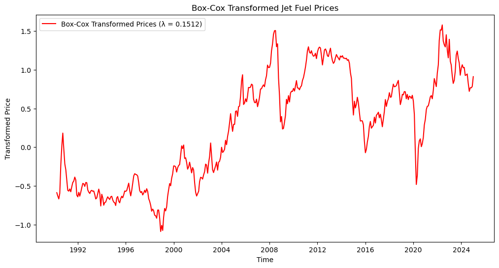

```python
import numpy as np
import matplotlib.pyplot as plt
from scipy.stats import boxcox

original_prices = jet_fuel_price["U.S. Gulf Coast Kerosene-Type Jet Fuel Spot Price FOB Dollars per Gallon"].dropna()

transformed_prices, lambda_val = boxcox(original_prices)

time_index = jet_fuel_price["Month"].dropna()

# Plot transformed data
plt.figure(figsize=(12, 6))
plt.plot(time_index, transformed_prices, label=f"Box-Cox Transformed Prices (λ = {lambda_val:.4f})", color="red")
plt.title("Box-Cox Transformed Jet Fuel Prices")
plt.ylabel("Transformed Price")
plt.xlabel("Time")
plt.legend()
plt.show()
```

The Box-Cox transformed jet fuel price series shows a more stabilized variance compared to the original series, but it still exhibits noticeable fluctuations, particularly during economic crises and oil price shocks. While the transformation reduces heteroscedasticity, there are still periods of high volatility, especially around 2008, 2014, and 2020. This suggests that additional modeling techniques, such as differencing or GARCH models, might be necessary to further address volatility in the series.

```python
jet_fuel_price
```

|  | Month | U.S. Gulf Coast Kerosene-Type Jet Fuel Spot Price FOB Dollars per Gallon | Transformed_Price |
| --- | --- | --- | --- |
| 0 | 2025-01-01 | 2.347 | 0.910609 |
| 1 | 2024-12-01 | 2.097 | 0.783556 |
| 2 | 2024-11-01 | 2.065 | 0.766376 |
| 3 | 2024-10-01 | 2.068 | 0.767997 |
| 4 | 2024-09-01 | 1.982 | 0.720740 |
| ... | ... | ... | ... |
| 413 | 1990-08-01 | 0.791 | -0.230350 |
| 414 | 1990-07-01 | 0.535 | -0.596821 |
| 415 | 1990-06-01 | 0.494 | -0.668922 |
| 416 | 1990-05-01 | 0.515 | -0.631383 |
| 417 | 1990-04-01 | 0.540 | -0.588352 |

418 rows × 3 columns

```python
air_traffic
```

| Date | Dom_Pax | Int_Pax | Pax | Dom_Flt | Int_Flt | Flt | Dom_RPM | Int_RPM | RPM | Dom_ASM | Int_ASM | ASM | Dom_LF | Int_LF | LF |
| --- | --- | --- | --- | --- | --- | --- | --- | --- | --- | --- | --- | --- | --- | --- | --- |
| 2003-01-01 | 0.828347 | 0.793857 | 0.820499 | 0.910438 | 0.871604 | 0.908376 | 0.793350 | 0.801216 | 0.790920 | 0.736973 | 0.784158 | 0.733187 | 0.668011 | 0.732539 | 0.695392 |
| 2003-02-01 | 0.814774 | 0.761803 | 0.804444 | 0.819246 | 0.829628 | 0.821181 | 0.775808 | 0.760013 | 0.765686 | 0.656956 | 0.738777 | 0.662510 | 0.716664 | 0.687736 | 0.723410 |
| 2003-03-01 | 0.874255 | 0.798454 | 0.861259 | 0.921217 | 0.879301 | 0.919042 | 0.836089 | 0.795618 | 0.819319 | 0.754120 | 0.780307 | 0.742419 | 0.773254 | 0.718660 | 0.774001 |
| 2003-04-01 | 0.855569 | 0.766968 | 0.841053 | 0.893171 | 0.854763 | 0.890714 | 0.819088 | 0.752706 | 0.795101 | 0.717485 | 0.737563 | 0.701000 | 0.769351 | 0.658169 | 0.759395 |
| 2003-05-01 | 0.869064 | 0.780110 | 0.854507 | 0.914252 | 0.856443 | 0.909859 | 0.830506 | 0.777249 | 0.810081 | 0.726473 | 0.739635 | 0.707688 | 0.793417 | 0.767989 | 0.799894 |
| ... | ... | ... | ... | ... | ... | ... | ... | ... | ... | ... | ... | ... | ... | ... | ... |
| 2023-05-01 | 0.983498 | 0.959543 | 0.978907 | 0.795213 | 0.950331 | 0.819013 | 0.976218 | 0.964832 | 0.971324 | 0.963621 | 0.967933 | 0.961351 | 0.945492 | 0.916428 | 0.947948 |
| 2023-06-01 | 0.988005 | 0.983570 | 0.986938 | 0.788772 | 0.966578 | 0.816535 | 0.985246 | 0.989113 | 0.986245 | 0.965737 | 0.982200 | 0.970276 | 0.976194 | 1.000000 | 0.991767 |
| 2023-07-01 | 1.000000 | 1.000000 | 1.000000 | 0.813669 | 0.987084 | 0.842057 | 1.000000 | 1.000000 | 1.000000 | 0.999903 | 1.000000 | 1.000000 | 0.976454 | 0.990647 | 0.989510 |
| 2023-08-01 | 0.983731 | 0.984100 | 0.983470 | 0.820406 | 0.975267 | 0.845561 | 0.981503 | 0.989524 | 0.983965 | 1.000000 | 0.996205 | 0.997983 | 0.907506 | 0.944486 | 0.928031 |
| 2023-09-01 | 0.963273 | 0.937849 | 0.958141 | 0.775812 | 0.910075 | 0.794892 | 0.953096 | 0.958672 | 0.953747 | 0.944829 | 0.960666 | 0.946362 | 0.890725 | 0.910243 | 0.906785 |

249 rows × 15 columns

```python
gdp_history.tail(10)
```

|  | Year-Month | Monthly Nominal GDP Index | Monthly Real GDP Index |
| --- | --- | --- | --- |
| 386 | 2024-03-01 | 28776.055738 | 23100.349514 |
| 387 | 2024-04-01 | 28925.771181 | 23164.936946 |
| 388 | 2024-05-01 | 29029.569124 | 23245.749041 |
| 389 | NaT | 29094.801696 | 23265.718891 |
| 390 | NaT | 29320.047090 | 23371.138228 |
| 391 | 2024-08-01 | 29414.807797 | 23435.600363 |
| 392 | 2024-09-01 | 29389.581757 | 23398.764115 |
| 393 | 2024-10-01 | 29672.497957 | 23535.572316 |
| 394 | 2024-11-01 | 29766.631873 | 23594.464516 |
| 395 | 2024-12-01 | 29686.041989 | 23482.006841 |

```python
# Ensure date columns are in datetime format
gdp_history['Year-Month'] = pd.to_datetime(gdp_history['Year-Month'])
jet_fuel_price['Month'] = pd.to_datetime(jet_fuel_price['Month'])

# Define the required date range
start_date = '2023-10-01'
end_date = '2024-09-01'
required_dates = pd.date_range(start=start_date, end=end_date, freq='MS')

# Filter datasets for the required date range
gdp_filtered = gdp_history[gdp_history['Year-Month'].isin(required_dates)]
jet_fuel_filtered = jet_fuel_price[jet_fuel_price['Month'].isin(required_dates)]

# Merge the datasets using an outer join to retain all required dates
merged_data = pd.merge(
    pd.DataFrame({'date': required_dates}),  # Ensures all required dates are included
    gdp_filtered[['Year-Month', 'Monthly Real GDP Index']],
    left_on='date', right_on='Year-Month',
    how='left'
).merge(
    jet_fuel_filtered[['Month', 'Transformed_Price']],
    left_on='date', right_on='Month',
    how='left'
)

# Drop redundant columns
merged_data = merged_data[['date', 'Transformed_Price', 'Monthly Real GDP Index']]

# Rename columns to match the required format
merged_data.columns = ['date', 'transformed_price', 'monthly_real_gdp']

# Manually correct NaT values for 2024-06-01 and 2024-07-01
merged_data.loc[merged_data['date'] == '2024-06-01', 'monthly_real_gdp'] = merged_data['monthly_real_gdp'].interpolate().iloc[-3]
merged_data.loc[merged_data['date'] == '2024-07-01', 'monthly_real_gdp'] = merged_data['monthly_real_gdp'].interpolate().iloc[-2]

# Save the final dataset as a CSV file
merged_data.to_csv('external_forecast.csv', index=False)
```

```python
merged_data
```

|  | date | transformed_price | monthly_real_gdp |
| --- | --- | --- | --- |
| 0 | 2023-10-01 | 1.147487 | 22800.801709 |
| 1 | 2023-11-01 | 1.086271 | 22924.607946 |
| 2 | 2023-12-01 | 0.929860 | 23161.118413 |
| 3 | 2024-01-01 | 1.021302 | 22957.850262 |
| 4 | 2024-02-01 | 1.064379 | 23107.200138 |
| 5 | 2024-03-01 | 1.024870 | 23100.349514 |
| 6 | 2024-04-01 | 1.030204 | 23164.936946 |
| 7 | 2024-05-01 | 0.926511 | 23245.749041 |
| 8 | 2024-06-01 | 0.933200 | 23372.316589 |
| 9 | 2024-07-01 | 0.945064 | 23435.600363 |
| 10 | 2024-08-01 | 0.825034 | 23435.600363 |
| 11 | 2024-09-01 | 0.720740 | 23398.764115 |